# 6 STATISTICAL LEARNING

#### Notation

| **symbol** | **meaning** |
| --- | --- |
| $a,b,c,N\dots$ | scalar number |
| $\boldsymbol{w},\boldsymbol{v},\boldsymbol{x},\boldsymbol{y}\dots$ | column vector |
| $\boldsymbol{X},\boldsymbol{Y}\dots$ | matrix |
| $\mathbb{R}$ | set of real numbers |
| $\mathbb{Z}$ | set of integer numbers |
| $\mathbb{N}$ | set of natural numbers |
| $\mathbb{R}^{D}$ | set of vectors |
| $\mathcal{D},\mathcal{X},\mathcal{Y},\dots$ | set |
| $\mathcal{A}$ | algorithm |

| **symbol** | **meaning** |
| --- | --- |
| $X,Y\dots$ | random variable |
| $\boldsymbol{X},\boldsymbol{Y}\dots$ | multivariate random variable |
| $x,y\dots$ | value |
| $\boldsymbol{x},\boldsymbol{y}\dots$ | vector |
| $p,pr,P,Pr$ | probability |

## 6.1 Probability And Statistics

#### Bayes Theorem

[figure not shown]

$$\begin{equation}
P(h\mid\mathcal{D})=\frac{P(\mathcal{D}\mid h)P(h)}{P(\mathcal{D})}
\end{equation}$$

- $P(h)$ = **prior probability** of hypothesis $h$
- $P(\mathcal{D})$ = prior probability of observed data $\mathcal{D}$
- $P(h\mid\mathcal{D})$ = probability of $h$ given $\mathcal{D}$ (called **posterior probability**)
- $P(\mathcal{D}\mid h)$ = probability of $\mathcal{D}$ given $h$ (called **likelihood**)

#### Basic Formulas for Probabilities

Given two random variables $X$ and $Y$, we say that

- The quantity $p(X,Y)$ is a *joint probability*
- The quantity $p(Y\mid X)$ is a *conditional probability*
- The quantity $p(X)$ is a *marginal probability*

#### Example 1

- We have the joint distribution of three random variables $P(Headache,Hurt,Cold)$

[figure not shown]

$$\begin{align*}
P(headache) & =0.108+0.012+0.016+0.064\\
& =0.2
\end{align*}$$

[figure not shown]

$$\begin{align*}
P(hurt\lor headache) & =0.108+0.012+0.072+0.008+0.016+0.064\\
& =0.28
\end{align*}$$

[figure not shown]

$$\begin{align}
P(\lnot hurt\mid headache) & = & \frac{P(\lnot hurt\land headache)}{P(headache)}\\
& = & \frac{0.016+0.064}{0.108+0.012+0.016+0.064}\\
& = & 0.4
\end{align}$$

Problem Let $\boldsymbol{X}$ be all the variables. We want the posterior joint distribution of the **query variables** $\boldsymbol{Y}$ given specific values $\boldsymbol{e}$ for the **evidence variables** $\boldsymbol{E}$

*Proof*. *Summing solution.*

- General idea: compute distribution on query variable by fixing **evidence variables** and summing over **hidden variables**
- Let the **hidden variables** be $\boldsymbol{H}=\boldsymbol{X}-\boldsymbol{Y}-\boldsymbol{E}$ and denominator can be viewed as a **normalization constant** $\alpha$
  $$\begin{equation}
  P(\boldsymbol{Y}\mid\boldsymbol{E}=\boldsymbol{e})=\alpha\:P(\boldsymbol{Y},\boldsymbol{E}=\boldsymbol{e})=\alpha\:\sum_{\boldsymbol{h}}P(\boldsymbol{Y},\boldsymbol{E}=\boldsymbol{e},\boldsymbol{H}=\boldsymbol{h})
  \end{equation}$$

◻

[figure not shown]

$$\begin{align}
& & P(Hurt\mid headache)\\
& = & \alpha\,P(Hurt,headache)\\
& = & \alpha\,[P(Hurt,headache,cold)+P(Hurt,headache,\lnot cold)]\\
& = & \alpha\,[\left\langle 0.108,0.016\right\rangle +\left\langle 0.012,0.064\right\rangle ]\\
& = & \alpha\,\left\langle 0.12,0.08\right\rangle \\
& = & \left\langle 0.6,0.4\right\rangle
\end{align}$$

## 6.2 Statistical Learning

#### Statistical Model

[figure not shown]

- All models are wrong, but some are useful (**statistical model**) - George Box

#### Probabilistic Approach

**Learning** is an estimation of *joint probability density* function $p(\boldsymbol{x},y)$ given observed data $\mathcal{D}$. **Inductive bias** is expressed as prior assumptions about these joint distributions.

- **Classification** and **Regression**: conditional density estimation
  $$\begin{equation}
  p(y\mid\boldsymbol{x})
  \end{equation}$$
- **Unsupervised Learning**: density estimation
  $$\begin{equation}
  p(\boldsymbol{x})
  \end{equation}$$

#### Type of Supervised Model

**Discriminative model**

**Generative model**

*Goal*

- Directly estimate $P(y\mid\boldsymbol{x})$
- Estimate $P(\boldsymbol{x}\mid y)$ to then deduce $P(y\mid\boldsymbol{x})$

*What’s learned*

- Decision boundary
- Probability distributions of the data

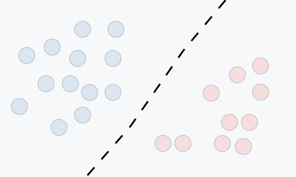

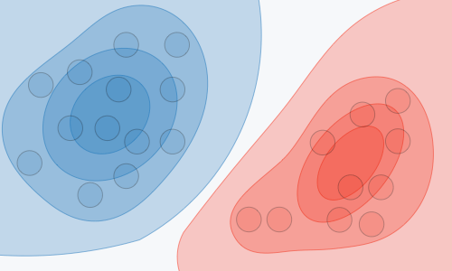

#### Bayesian Learning

**Bayesian learning** is a process that updates of a probability distribution (**belief**) over the **hypothesis space** $\mathcal{H}=\{h_{1},h_{2},...\}$ given samples $\mathcal{D}$.

- Prior probability of each hypothesis $h_{i}$
  $$\begin{equation}
  P(h_{i})
  \end{equation}$$
- Given the data $\mathcal{D}$, each hypothesis has a posterior probability (update)
  $$\begin{equation}
  P(h_{i}\mid\mathcal{D})=\alpha P(\mathcal{D}\mid h_{i})P(h_{i})
  \end{equation}$$
- Predictions use **an average** over the hypotheses
  $$\begin{equation}
  P(d)=\sum_{i}P(d\mid h_{i})P(h_{i})
  \end{equation}$$

#### Components of Learning

[figure not shown]

#### Evolution of Posterior Probabilities

- Changes of a probability distribution $P(h)$ after observing the data $D_{1}$ and $D_{2}$

[figure not shown]

#### Example 1

- Does patient have COVID or not?

  > “A patient takes a lab test and the result comes back positive. The test returns a correct positive result in only $98\%$ of the cases in which the disease is actually present, and a correct negative result in only $97\%$ of the cases in which the disease is not present. Furthermore, $.008$ of the entire population have this COVID.”

*Proof*. *Solution.*

| $P(COVID)$ | = | ______ | $P(\neg COVID)$ | = | ______ |
| --- | --- | --- | --- | --- | --- |
| $P(\oplus\mid COVID)$ | = | ______ | $P(\ominus\mid COVID)$ | = | ______ |
| $P(\oplus\mid\neg COVID)$ | = | ______ | $P(\ominus\mid\neg COVID)$ | = | ______ |

◻

#### Example 2

- Suppose there are five kinds of bags of candies:
  - 10% are $h_{1}$: 100% cherry candies
  - 20% are $h_{2}$: 75% cherry candies + 25% lime candies
  - 40% are $h_{3}$: 50% cherry candies + 50% lime candies
  - 20% are $h_{4}$: 25% cherry candies + 75% lime candies
  - 10% are $h_{5}$: 100% lime candies

[figure not shown]

**Experiment**

- Select one bag
- Candies drawn from the bag:

[figure not shown]

**Question**

1. What kind of bag is it?
2. What flavour will the next candy be?
3. What kind of bag is it?

   Posterior probability of hypotheses

[figure not shown]

4. What flavour will the next candy be?

   Prediction probability

[figure not shown]

#### Exercise

- Suppose we have a box of dice that contains a 4-sided die, a 6-sided die, an 8-sided die, a 12-sided die, and a 20-sided die

[figure not shown]

**Experiment**

- We select one die
- We roll the die a few more times and get $\mathcal{D}=\{6,8,7,7,5,4\}$

**Question**

1. What die is selected?

## 6.3 Fitting Models

#### Learning Strategy

Fitting probability models to data $\mathcal{D}=\left\{ \boldsymbol{x}_{1},...\boldsymbol{x}_{n}\right\}$ is referred to as *learning* because we learn about the parameters **$\theta$** of the model

- **Updating** or **summing** over the hypothesis space is often intractable (e.g., 18,446,744,073,709,551,616 Boolean functions of 6 attributes)
- Alternative strategies:
  - **Maximum a posteriori** (MAP) learning
  - **Maximum likelihood** (ML) learning

#### Maximum a posteriori

Given data $\mathcal{D}$

- choose hypothesis $h$ (called $h_{MAP}$) maximizing $P(h\mid\mathcal{D}$)
- i.e., maximize $P(\mathcal{D}\mid h)P(h)$ or $\log P(\mathcal{D}\mid h)+\log P(h)$

[figure not shown]

#### Maximum likelihood

- For large data sets, prior becomes weak or irrelevant**, maximum likelihood** learning
- Given data $\mathcal{D}$, choose hypothesis $h$ (called $h_{ML}$) maximizing $P(\mathcal{D}\mid h)$ or $\log P(\mathcal{D}\mid h)$

[figure not shown]

### One categorical variable

#### Example 1

- A bag containing two kinds of candies, lime and cherry, has a fraction ${\color{red}\theta}$ of cherry candies?

[figure not shown]

  **Experiment**
  - Candies drawn from the bag:

[figure not shown]

  **Question**
  1. What the value of ${\color{red}\theta}$ is?

*Proof*. *ML learning solution.*

- The model (Bayes net) has one variable *flavor* with one parameter ${\color{red}\theta}$

[figure not shown]

- Any ${\color{red}\theta}\in[0,1]$ is possible: continuum of hypotheses $h_{{\color{red}\theta}}$
- ${\color{red}\theta}$ is a **parameter** for this simple (**binomial**) family of models
- Suppose we unwrap $N$ candies, $c$ cherries and $\ell=N-c$ limes. These are **i.i.d.** (independent, identically distributed) observations, so
  $$p(\mathcal{D}\mid h_{{\color{red}\theta}})=\prod_{j=1}^{N}p(d_{j}\mid h_{{\color{red}\theta}})={\color{red}\theta}^{c}\cdot(1-{\color{red}\theta})^{\ell}$$
- Maximize this w.r.t. ${\color{red}\theta}$—which is easier for the **log-likelihood**:
  $$\begin{align}
  L(\mathcal{D}\mid h_{{\color{red}\theta}}) & = & \log p(\mathcal{D}\mid h_{{\color{red}\theta}})\nonumber \\
  & = & \sum_{j=1}^{N}\log p(d_{j}\mid h_{{\color{red}\theta}})\nonumber \\
  & = & c\log{\color{red}\theta}+\ell\log(1-{\color{red}\theta})\nonumber \\
  \frac{dL(\mathcal{D}\mid h_{{\color{red}\theta}})}{d{\color{red}\theta}} & = & \frac{c}{{\color{red}\theta}}-\frac{\ell}{1-{\color{red}\theta}}=0\nonumber \\
  \implies{\color{red}\theta_{ML}} & = & \frac{c}{c+\ell}=\frac{c}{N}
  \end{align}$$

◻

- ML seems sensible, but causes problems with **0 counts**!

*Proof*. *MAP learning solution.*

- Prior for $h_{{\color{red}\theta}}$
  $$p(h_{{\color{red}\theta}})=Beta(a,b)\text{ where }a,b>0,$$
- Posteriori for $h_{{\color{red}\theta}}$ given $\mathcal{D}$
  $$\begin{align*}
  p(h_{{\color{red}\theta}}\mid\mathcal{D}) & \propto p(\mathcal{D}\mid h_{{\color{red}\theta}})p(h_{{\color{red}\theta}})\\
  & =Beta(a+c,b+\ell)
  \end{align*}$$
- MAP estimate
  $$\begin{equation}
  {\color{red}\theta_{MAP}}=\frac{c+a-1}{c+\ell+a+b-2}
  \end{equation}$$

[figure not shown]

◻

### Two categorical variables

#### Example 2

- A bag has a fraction ${\color{red}\theta}$ of cherry candies, red/green *wrapper* depends probabilistically ${\color{red}\theta_{1}},{\color{red}\theta_{2}}$ on *flavor*?

[figure not shown]

  **Experiment**
  - Candies drawn from some bag $\mathcal{D}$

[figure not shown]

  **Question**
  1. What the values of ${\color{red}\theta},{\color{red}\theta_{1}},{\color{red}\theta_{2}}$ are?

*Proof*. *ML learning solution.*

- The model (Bayes net) has two variables *flavor* and *wrapper* with three parameters ${\color{red}\theta},{\color{red}\theta_{1}},{\color{red}\theta_{2}}$

[figure not shown]

- Likelihood for, e.g., cherry candy in green wrapper:
  $$\begin{array}{l}
  p(F=cherry,W=green\mid h_{{\color{red}\theta},{\color{red}\theta_{1}},{\color{red}\theta_{2}}})\\
  =p(F=cherry\mid h_{{\color{red}\theta},{\color{red}\theta_{1}},{\color{red}\theta_{2}}})p(W=green\mid F=cherry;h_{{\color{red}\theta},{\color{red}\theta_{1}},{\color{red}\theta_{2}}})\\
  ={\color{red}\theta}\cdot(1-{\color{red}\theta_{1}})
  \end{array}$$
- $N$ candies, $r_{c}$ red-wrapped cherry candies, etc.:
  $$\begin{align}
  p(\mathcal{D}\mid h_{{\color{red}\theta},{\color{red}\theta_{1}},{\color{red}\theta_{2}}}) & = & {\color{red}\theta}^{c}(1-{\color{red}\theta})^{\ell}\cdot{\color{red}\theta}_{{\color{red}1}}^{r_{c}}(1-{\color{red}\theta_{1}})^{g_{c}}\cdot{\color{red}\theta}_{{\color{red}2}}^{r_{\ell}}(1-{\color{red}\theta_{2}})^{g_{\ell}}
  \end{align}$$

  $$\begin{align}
  L & = & [c\log{\color{red}\theta}+\ell\log(1-{\color{red}\theta})]\\
  & & +[r_{c}\log{\color{red}\theta}_{{\color{red}1}}+g_{c}\log(1-{\color{red}\theta_{1}})]\\
  & & +[r_{\ell}\log{\color{red}\theta_{2}}+g_{\ell}\log(1-{\color{red}\theta_{2}})]
  \end{align}$$
- Derivatives of $L$ contain only the relevant parameter:
  $$\begin{array}{rclcl}
  {\displaystyle \frac{\partial L}{\partial{\color{red}\theta}}} & = & {\displaystyle \frac{c}{{\color{red}\theta}}-{\displaystyle \frac{\ell}{1-{\color{red}\theta}}=0}} & \implies & {\color{red}\theta}={\displaystyle \frac{c}{c+\ell}}\end{array}$$

  $$\begin{array}{rclcl}
  {\displaystyle \frac{\partial L}{\partial{\color{red}\theta_{1}}}} & = & {\displaystyle \frac{r_{c}}{{\color{red}\theta_{1}}}-{\displaystyle \frac{g_{c}}{1-{\color{red}\theta_{1}}}=0}} & \implies & {\color{red}\theta_{1}}={\displaystyle \frac{r_{c}}{r_{c}+g_{c}}}\end{array}$$

  $$\begin{array}{rclcl}
  {\displaystyle \frac{\partial L}{\partial{\color{red}\theta_{2}}}} & = & {\displaystyle \frac{r_{\ell}}{{\color{red}\theta_{2}}}-{\displaystyle \frac{g_{\ell}}{1-{\color{red}\theta_{2}}}=0}} & \implies & {\color{red}\theta_{2}}={\displaystyle \frac{r_{\ell}}{r_{\ell}+g_{\ell}}}\end{array}$$
- With **complete data**, *parameters can be learned separately*

◻

### One continuous variable

#### Example 3

- Suppose that the distribution of male height is a normal distribution $\mathcal{N}({\color{red}\mu},{\color{red}\sigma}^{2})$. Given the following data $\mathcal{D}$

  | # | height (m) |  | # | height (m) |
  | --- | --- | --- | --- | --- |
  | 1 | 1.72 |  | 6 | 1.63 |
  | 2 | 1.65 |  | 7 | 1.74 |
  | 3 | 1.60 |  | 8 | 1.82 |
  | 4 | 1.73 |  | 9 | 1.75 |
  | 5 | 1.80 |  | 10 | 1.64 |

  **Question**: what are the values of ${\color{red}\mu},{\color{red}\sigma}$?

*Proof*. *ML learning solution.*

- The model has one variable *$x$* (*height*) with two parameters ${\color{red}\mu},{\color{red}\sigma}^{2}$
  $$\begin{equation}
  p(x\mid{\color{red}\mu},{\color{red}\sigma}^{2})=\mathcal{N}(x\mid{\color{red}\mu},{\color{red}\sigma}^{2})=\frac{1}{\sqrt{2\pi{\color{red}\sigma}^{2}}}\exp\left[-\frac{(x-{\color{red}\mu})^{2}}{2{\color{red}\sigma}^{2}}\right]
  \end{equation}$$
- The likelihood of model with the parameters $\{{\color{red}\mu},{\color{red}\sigma}^{2}\}$ for observed i.d.d. data $\mathcal{D}=\{x_{1},...,x_{n}\}$ is
  $$\begin{align}
  p(\mathcal{D}\mid{\color{red}\mu},{\color{red}\sigma}^{2}) & = & \prod_{i=1}^{n}\mathcal{N}(x_{i}\mid{\color{red}\mu},{\color{red}\sigma}^{2})\nonumber \\
  & = & \frac{1}{(2\pi{\color{red}\sigma}^{2})^{n/2}}\exp\left[-\frac{1}{2}\sum_{i=1}^{n}\frac{(x_{i}-{\color{red}\mu})^{2}}{{\color{red}\sigma}^{2}}\right]
  \end{align}$$
- The maximum likelihood solution ${\color{red}\mu_{ML}}$, ${\color{red}\sigma}_{{\color{red}ML}}^{2}$
  $$\begin{equation}
  {\color{red}\mu_{ML}},{\color{red}\sigma}_{{\color{red}ML}}^{2}=\text{argmax}_{{\color{red}\mu},{\color{red}\sigma}^{2}}[p(\mathcal{D}\mid{\color{red}\mu},{\color{red}\sigma}^{2})]
  \end{equation}$$

[figure not shown]

- Since the logarithm is a monotonic function, the position of the maximum in the transformed function $L=\log p(\mathcal{D}\mid{\color{red}\mu},{\color{red}\sigma}^{2})$ remains the same as $p(\mathcal{D}\mid{\color{red}\mu},{\color{red}\sigma}^{2})$
- The maximum *log-likelihood* solution
  $$\begin{align}
  {\color{red}\mu_{ML}},{\color{red}\sigma}_{{\color{red}ML}}^{2} & = & \text{argmax}_{{\color{red}\mu},{\color{red}\sigma}^{2}}[\log p(\mathcal{D}\mid{\color{red}\mu},{\color{red}\sigma}^{2})]\nonumber \\
  & = & \text{argmax}_{{\color{red}\mu},{\color{red}\sigma}^{2}}\left[-\frac{1}{2}n\log[2\pi]-\frac{1}{2}\log{\color{red}\sigma}^{2}-\frac{1}{2}\sum_{i=1}^{n}\frac{(x_{i}-{\color{red}\mu})^{2}}{{\color{red}\sigma}^{2}}\right].
  \end{align}$$
- To maximize, we differentiate this *log-likelihood $L$* with respect to $\mu$ and equate the result to zero
  $$\begin{align}
  \frac{\partial L}{\partial{\color{red}\mu}} & = & \sum_{i=1}^{n}\frac{(x_{i}-{\color{red}\mu})}{{\color{red}\sigma}^{2}}\nonumber \\
  & = & \frac{\sum_{i=1}^{n}x_{i}}{{\color{red}\sigma}^{2}}-\frac{n{\color{red}\mu}}{{\color{red}\sigma}^{2}}=0\nonumber \\
  {\color{red}\mu_{ML}} & = & \frac{1}{n}\sum_{i=1}^{n}x_{i}
  \end{align}$$
- By a similar process, the expression for the variance can be shown to be

$$\begin{equation}
{\color{red}\sigma}_{{\color{red}ML}}^{2}=\frac{1}{n}\sum_{i=1}^{n}(x_{i}-{\color{red}\mu_{ML}})^{2}.
\end{equation}$$
◻

### Joint Probability Distributions

#### Joint Probability Distributions

- The joint probability distribution is central to probabilistic inference, because once we know the joint distribution we can answer every possible probabilistic question that can be asked about these variables.

  | **Gender** | **HoursWorked** | **Wealth** | **probability** |
  | --- | --- | --- | --- |
  | female | $<40.5$ | poor | 0.2531 |
  | female | $<40.5$ | rich | 0.0246 |
  | female | $\geq40.5$ | poor | 0.0422 |
  | female | $\geq40.5$ | rich | 0.0116 |
  | male | $<40.5$ | poor | 0.3313 |
  | male | $<40.5$ | rich | 0.0972 |
  | male | $\geq40.5$ | poor | 0.1341 |
  | male | $\geq40.5$ | rich | 0.1059 |

#### Discussion

- How can we learn joint distributions from observed training data $\mathcal{D}$?

## 6.4 Linear Regression Revisited

#### Linear Regression

- Linear regression without prior belief

[figure not shown]

- Linear regression with prior belief

[figure not shown]

#### Linear Regression Revisited

[figure not shown]

- Unknown function $f$ is modeled by the hypothesis $h_{{\color{red}\boldsymbol{w}}}$
  $$\begin{equation}
  y=h_{\boldsymbol{{\color{red}w}}}(x)=\boldsymbol{{\color{red}w}}^{\intercal}\boldsymbol{x}+\epsilon
  \end{equation}$$
  where $y$ is noisy target value, $\epsilon$ is *random variable* (**noise**) drawn independently according to a Gaussian distribution with mean equal to 0 and variance equal to ${\color{red}\sigma}$ ($\mathcal{N}(0,{\color{red}\sigma}^{2})$)
- Probability language
  $$\begin{equation}
  p(y\mid\boldsymbol{x},{\color{red}\boldsymbol{w}})=\mathcal{N}(y\mid\boldsymbol{{\color{red}w}}^{\intercal}\boldsymbol{x},{\color{red}\sigma}^{2})
  \end{equation}$$
- Given data $\mathcal{D}=\{\boldsymbol{x}_{i},y_{i}\}_{i=1}^{N}$, the likelihood of $\mathcal{D}$ given $h_{{\color{red}\boldsymbol{w}}}$ and noise

$$\begin{equation}
\begin{array}{rcl}
p(\mathcal{D}\mid h_{\boldsymbol{{\color{red}w}}},\epsilon) & = & \prod_{i=1}^{N}p(y_{i}\mid\boldsymbol{x}_{i},\boldsymbol{{\color{red}w}})\\
& = & \prod_{i=1}^{N}\mathcal{N}(y_{i}\mid\boldsymbol{{\color{red}w}}^{\intercal}\boldsymbol{x}_i,{\color{red}\sigma}^{2})
\end{array}
\end{equation}$$

#### ML Learning

Choose hypothesis $h$ maximizing the likelihood
$$\begin{equation}
\begin{array}{cl}
& \arg\max_{\boldsymbol{{\color{red}w}},{\color{red}\sigma}}p(\mathcal{D}\mid h_{\boldsymbol{{\color{red}w}}},e)\\
\Leftrightarrow & \arg\max_{\boldsymbol{{\color{red}w}},{\color{red}\sigma}}\prod_{i=1}^{N}\mathcal{N}(y_{i}\mid\boldsymbol{{\color{red}w}}^{\intercal}\boldsymbol{x}_{i},{\color{red}\sigma}^{2})\\
\Leftrightarrow & \arg\max_{\boldsymbol{{\color{red}w}},{\color{red}\sigma}}\log\left(\prod_{i=1}^{N}\mathcal{N}(y_{i}\mid\boldsymbol{{\color{red}w}}^{\intercal}\boldsymbol{x}_{i},{\color{red}\sigma}^{2})\right)\\
\Leftrightarrow & \arg\min_{\boldsymbol{{\color{red}w}},{\color{red}\sigma}}\dfrac{1}{2{\color{red}\sigma}^{2}}MSE+\dfrac{N}{2}\log({\color{red}\sigma}^{2})+\dfrac{N}{2}\log(2\pi)
\end{array}
\end{equation}$$

Solving (20), we have

$$\boldsymbol{{\color{red}w}}_{ML}=(\boldsymbol{X}^{\intercal}\boldsymbol{X})^{-1}\boldsymbol{X}^{\intercal}\boldsymbol{y}$$

$${\color{red}\sigma}_{ML}^{2}=\frac{1}{N}\sum_{i=1}^{N}({\color{red}\boldsymbol{w}}_{ML}^{\intercal}\boldsymbol{x}_{i}-y_{i})^{2}$$

#### Example

- The red curve denotes the regression curve and the red region corresponds to $\pm{\color{red} \sigma}$ standard deviation

[figure not shown]

#### Bayesian Learning

- The figure shows the update process of Bayesian learning where $\boldsymbol{{\color{red}w}}$ are introduced as hypothesis parameters

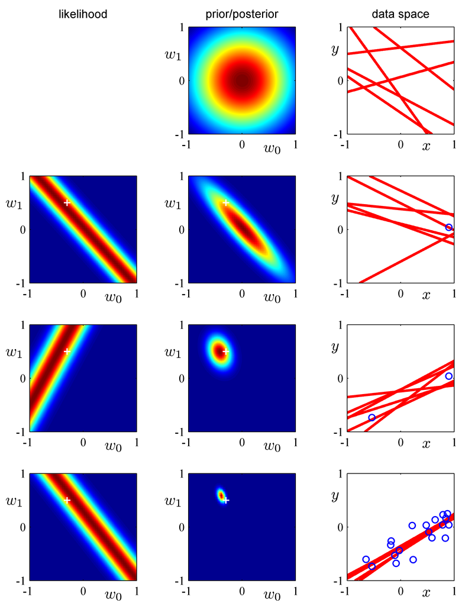

## 6.5 Naive Bayes

#### When to use

Along with decision trees, neural networks, nearest neighbour, one of the most practical learning methods.

- Moderate or large training set available
- Attributes that describe instances are conditionally independent given classification

Successful applications

- Diagnosis
- Classifying text documents

#### Naive Bayes assumption

- Assume target function for classification problem
  $$f:\mathcal{X}\rightarrow\mathcal{Y}$$
  where each instance $\boldsymbol{x}$ described by attributes $(x_{1},x_{2}\ldots x_{D})$ and $y$ is a corresponding class.
- **Naive Bayes assumption**
  $$\begin{equation}
  P(x_{1},x_{2}\ldots x_{D}\mid y)=\prod_{i=1}^{D}P(x_{i}\mid y)
  \end{equation}$$

#### Naive Bayes classifiers

- **Naive Bayes classifier**

$$\begin{equation}
y_{NB}=\arg\max_{y}\hat{P}(y)\prod_{i=1}^{D}\hat{P}(x_{i}\mid y)
\end{equation}$$

The form of the class-conditional density depends on the type of each feature.

1. In the case of real-valued features, we can use the **Gaussian distribution**:
   $$p(\boldsymbol{x}\mid y=c)\sim\prod_{j=1}^{D}\mathcal{N}(x_{j}\mid{\color{red}\mu_{jc}},{\color{red}\sigma_{jc}^{2}})$$
   where ${\color{red}\mu}_{{\color{red}jc}}$ is the mean of feature $j$ in objects of class $c$, and ${\color{red}\sigma}_{{\color{red}jc}}^{{\color{red}2}}$ is its variance.
2. In the case of binary features, $x_{j}\in\{0,1\}$, we can use the **Bernoulli distribution**:
   $$p(\boldsymbol{x}\mid y=c)\sim\prod_{j=1}^{D}\text{Ber}(x_{j}\mid{\color{red}\mu_{jc}})$$
   where ${\color{red}\mu}_{{\color{red}jc}}$ is the probability that feature $j$ occurs in class $c$.
3. In the case of categorical features, $x_{j}\in\{v_{j_{1}},v_{j_{2}},\cdots,v_{j_{K}}\}$, we can use the **multinoulli distribution**:
   $$p(\boldsymbol{x}\mid y=c)\sim\prod_{j=1}^{D}\text{Cat}(x_{j}\mid{\color{red}\boldsymbol{\mu}}_{{\color{red}jc}})$$
   where ${\color{red}\boldsymbol{\mu}}_{{\color{red}jc}}$ is a histogram over the $K$ possible values for $x_{j}$ in class $c$.

#### Naive Bayes Algorithm

LearnNaiveBayes($\mathcal{D}$)

**for** each target value (class) $y_{j}$

$\hat{P}(y_{j})$ $\leftarrow$ estimate $P(y_{j})$ given data $\mathcal{D}$

**for** each attribute $x_{i}$

$\hat{P}(x_{i}\mid y_{j})$ $\gets$ estimate $P(x_{i}\mid y_{j})$ given data $\mathcal{D}$

ClassifyNewInstance($x$)

$y=\arg\max_{y}\hat{P}(y)\prod_{i=1}^{D}\hat{P}(x_{i}\mid y)$

**return** $y$

**Maximum likelihood learning** for $\hat{P}(y=c)$ and $\hat{P}(x_{i}=a\mid y=c)$
$$\begin{equation}
\hat{P}(y=c)\gets\frac{n_{c}}{n}
\end{equation}$$

$$\begin{equation}
\hat{P}(x_{i}=a\mid y=c)\leftarrow\frac{n_{a}}{n_{c}}
\end{equation}$$
where

- $n$ is number of training examples
- $n_{c}$ is number of training examples for which $y=c$
- $n_{a}$ is number of examples for which $y=c$ and $x_{i}=a$

#### Example 1

- Consider *PlayTennis* again

  | **Day** | **Outlook** | **Temperature** | **Humidity** | **Wind** | **PlayTennis?** |
  | --- | --- | --- | --- | --- | --- |
  | D1 | sunny | hot | high | weak | no |
  | D2 | sunny | hot | high | strong | no |
  | D3 | overcast | hot | high | weak | yes |
  | D4 | rain | mild | high | weak | yes |
  | D5 | rain | cool | normal | weak | yes |
  | D6 | rain | cool | normal | strong | no |
  | D7 | overcast | cool | normal | strong | yes |
  | D8 | sunny | mild | high | weak | no |
  | D9 | sunny | cool | normal | weak | yes |
  | D10 | rain | mild | normal | weak | yes |
  | D11 | sunny | mild | normal | strong | yes |
  | D12 | overcast | mild | high | strong | yes |
  | D13 | overcast | hot | normal | weak | yes |
  | D14 | rain | mild | high | strong | no |

- Naive Bayes model

| $\hat{P}(PlayTennis)$ yes 9/14 no 5/14 |  |
| --- | --- |
| $\hat{P}(Outlook\mid PlayTennis)$ $Outlook$ overcast rain sunny $PlayTennis$ yes 4/9 3/9 2/9 no 0/5 2/5 3/5 | $\hat{P}(Temperature\mid PlayTennis)$ $Temperature$ cool hot mild $PlayTennis$ yes 3/9 2/9 4/9 no 1/5 2/5 2/5 |
| $\hat{P}(Humidity\mid PlayTennis)$ $Humidity$ high normal $PlayTennis$ yes 3/9 6/9 no 4/5 1/5 | $\hat{P}(Wind\mid PlayTennis)$ $Wind$ strong weak $PlayTennis$ yes 3/9 6/9 no 3/5 2/5 |

- Get new instance

  $\boldsymbol{x}=(Outlk=sun,Temp=cool,Humid=high,Wind=strong)$
- Compute

  $\begin{cases} \hat{P}(yes)\times\hat{P}(sun\mid yes)\times\hat{P}(cool\mid yes)\times\hat{P}(high\mid yes)\times\hat{P}(strong\mid yes) & =.005\\ \hat{P}(no)\times\hat{P}(sun\mid no)\times\hat{P}(cool\mid no)\times\hat{P}(high\mid no)\times\hat{P}(strong\mid no) & =.021 \end{cases}$
- Make decison

  $y=no$

#### Example 2

- Find Naive Bayes classifier given the following training dataset

  | **#** | **Vị** | **Màu** | **Vỏ** | **Độc tính** |
  | --- | --- | --- | --- | --- |
  | 1 | ngọt | đỏ | nhẵn | không |
  | 2 | cay | đỏ | nhẵn | có |
  | 3 | chua | vàng | có gai | không |
  | 4 | cay | vàng | có gai | có |
  | 5 | ngọt | tím | có gai | không |
  | 6 | chua | vàng | nhẵn | không |
  | 7 | ngọt | tím | nhẵn | không |
  | 8 | cay | tím | có gai | có |
  | 9 | cay | tím | có gai | không |
  | 10 | cay | tím | có gai | có |
  | 11 | cay | vàng | có gai | có |

#### Avoiding the zero-probability problem

1. Conditional independence assumption is often violated but it works surprisingly well anyway
2. Suppose that none of the training instances with target value $y$ have attribute value $x_{i}=v$? then $\hat{P}(x_{i}=v\mid y)=0$, and $\hat{P}(y)\dots\hat{P}(x_{i}=v\mid y)\dots=0$ (not good in probability language)

Typical solution is **Bayesian estimate** for $\hat{P}(y=c)$ and $\hat{P}(x_{i}=a\mid y=c)$
$$\begin{equation}
\hat{P}(y=c)\gets\frac{n_{c}+1}{n+C}
\end{equation}$$

$$\begin{equation}
\hat{P}(x_{i}=a\mid y=c)\leftarrow\frac{n_{a}+1}{n_{c}+r}
\end{equation}$$
where

- $n$ is number of training examples
- $n_{c}$ is number of training examples for which $y=c$
- $C$ is the number of classes
- $n_{a}$ is number of examples for which $y=c$ and $x_{i}=a$
- $r$ is the number of values of attribute $x_{i}$

#### Example 3

- Find Naive Bayes classifier given the following training dataset

  | # | Height (m) | Hair | Gender |
  | --- | --- | --- | --- |
  | 1 | 1.72 | brown | male |
  | 2 | 1.65 | black | female |
  | 3 | 1.60 | black | female |
  | 4 | 1.73 | black | female |
  | 5 | 1.80 | brown | male |
  | 6 | 1.63 | black | male |
  | 7 | 1.74 | black | female |
  | 8 | 1.82 | brown | male |
  | 9 | 1.75 | black | male |
  | 10 | 1.64 | brown | female |

## 6.6 Statistical Language Model

#### Language Models

A **language model** is a function $p_{\text{\text{lm}}}$ that takes an English (or any language) sentence and returns the probability that it was produced by an English speaker

[figure not shown]

- Answer the question: How likely is a string of English (or any language) words good English?
- Help with reordering
  $$p_{\text{\text{lm}}}(\text{the house is small})>p_{\text{\text{lm}}}(\text{small the is house})$$
- Help with word choice
  $$p_{\text{\text{lm}}}(\text{I am going home})>p_{\text{\text{lm}}}(\text{I am going house})$$
- **Given** a string of English words $W=w_{1},w_{2},w_{3},...,w_{n}$. **Question**: what is $p(W)$?
- Decomposing $p(W)$ using the chain rule:
  $$\begin{equation}
  p(w_{1},w_{2},w_{3},...,w_{n})=p(w_{1})\;p(w_{2}|w_{1})\;p(w_{3}|w_{1},w_{2})...p(w_{n}|w_{1},w_{2},...w_{n-1})
  \end{equation}$$
- The language model probability $p(w_{1},w_{2},w_{3},...,w_{n})$ is a product of word history probabilities given a **history** of preceding words.

#### Markov Assumption

**Markov assumption** states that only a limited number of previous words affect the probability of the next word.

- limited memory: only last $k$ words are included in history (older words less relevant) $\rightarrow$ **$k$**th order Markov model

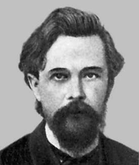

#### N-Gram Language Models

- Unigram (1-gram) model
  $$\begin{equation}
  p(w_{1},w_{2},w_{3},...,w_{n})=p(w_{1})\;p(w_{2})\;p(w_{3})...p(w_{n})
  \end{equation}$$
- Bigram (2-gram) model
  $$\begin{equation}
  p(w_{1},w_{2},w_{3},...,w_{n})={\color{lightgray}p(w_{1}}\mathclose{\color{lightgray})}\;p(w_{2}|w_{1})\;p(w_{3}|w_{2})...p(w_{n}|w_{n-1})
  \end{equation}$$
- Trigram (3-gram) model
  $$\begin{equation}
  p(w_{1},w_{2},w_{3},...,w_{n})={\color{lightgray}p(w_{1})\;p(w_{2}|w_{1}}\mathclose{\color{lightgray})}\;p(w_{3}|w_{1},w_{2})...p(w_{n}|w_{n-2},w_{n-1})
  \end{equation}$$

#### Estimating N-Gram Probabilities

- Maximum likelihood estimation for 1-gram
  $$\begin{equation}
  p_{\text{\text{lm}}}(w_{1})=\frac{\text{count}(w_{1})}{\text{the total number of words}}
  \end{equation}$$
- Maximum likelihood estimation for 2-gram
  $$\begin{equation}
  p_{\text{\text{lm}}}(w_{2}|w_{1})=\frac{\text{count}(w_{1},w_{2})}{\text{count}(w_{1})}
  \end{equation}$$
- Maximum likelihood estimation for 3-gram
  $$\begin{equation}
  p_{\text{\text{lm}}}(w_{3}|w_{1},w_{2})=\frac{\text{count}(w_{1},w_{2},w_{3})}{\text{count}(w_{1},w_{2})}
  \end{equation}$$

#### Example 1

Given a corpus

```
<s> I am Sam </s>
<s> Sam I am </s>
<s> I do not like ham </s>
```

Some of the bigram probabilities from this corpus
$$p_{\text{\text{lm}}}(w_{2}|w_{1})=\frac{\text{count}(w_{1},w_{2})}{\text{count}(w_{1})}$$

$p_{\text{\text{lm}}}(\text{\texttt{I}}|\text{\texttt{<s>}})=$$\frac{2}{3}=0.67$

$p_{\text{\text{lm}}}(\text{\texttt{Sam}}|\text{\texttt{<s>}})=$$\frac{1}{3}=0.33$

$p_{\text{\text{lm}}}(\text{\texttt{am}}|\text{\texttt{I}})=$$\frac{2}{3}=0.67$

$p_{\text{\text{lm}}}(\text{\texttt{do}}|\text{\texttt{I}})=$$\frac{1}{3}=0.33$

$p_{\text{\text{lm}}}(\text{\texttt{Sam}}|\text{\texttt{am}})=$$\frac{1}{2}=0.5$

$p_{\text{\text{lm}}}(\text{\texttt{</s>}}|\text{\texttt{Sam}})=$$\frac{1}{2}=0.5$

#### Exercise 1

Given a corpus

```
<s> Tôi là nam </s>
<s> Bạn tôi là nữ </s>
<s> Tôi thích trà </s>
```

Compute all the bigram probabilities from this corpus

#### Example 2

- Bigram probabilities for eight words (out of $V=1446$) in the Berkeley Restaurant Project corpus of 9332 sentences. Zero probabilities are in gray

[figure not shown]

- And a few other useful probabilities
  $$\begin{array}{ll}
  p_{\text{\text{lm}}}(\text{\texttt{i}}|\text{\texttt{<s>}})=0.25 & p_{\text{\text{lm}}}(\text{\texttt{english}}|\text{\texttt{want}})=0.0011\\
  p_{\text{\text{lm}}}(\text{\texttt{food}}|\text{\texttt{english}})=0.5 & p_{\text{\text{lm}}}(\text{\texttt{</s>}}|\text{\texttt{food}})=0.68
  \end{array}$$
- Compute the probability of sentences like `I want English food` or `I want Chinese food`
- The probability of sentence `I want English food` $\to$ `<s> i want english food </s>`

  | # | $p(w_{2}\|w_{1})$ | value |
  | --- | --- | --- |
  | 1 | $p_{\text{\text{lm}}}(\text{\texttt{i}}\|\text{\texttt{<s>}})$ | 0.25 |
  | 2 | $p_{\text{\text{lm}}}(\text{\texttt{want}}\|\text{\texttt{i}})$ | 0.33 |
  | 3 | $p_{\text{\text{lm}}}(\text{\texttt{english}}\|\text{\texttt{want}})$ | 0.0011 |
  | 4 | $p_{\text{\text{lm}}}(\text{\texttt{food}}\|\text{\texttt{english}})$ | 0.5 |
  | 5 | $p_{\text{\text{lm}}}(\text{\texttt{</s>}}\|\text{\texttt{food}})$ | 0.68 |
  |  | total | 0.000031 |

#### Practical Issues

We do everything in log space

- Avoid underflow
- Adding is faster than multiplying

$$\begin{equation}
\log(p_{1}\times p_{2}\times...\times p_{n})=\log(p_{1})+\log(p_{2})+...+\log(p_{n})
\end{equation}$$

| # | $(w_{2}\|w_{1})$ | $p_{\text{\text{lm}}}(w_{2}\|w_{1})$ | $\log_{2}p_{\text{\text{lm}}}(w_{2}\|w_{1})$ |
| --- | --- | --- | --- |
| 1 | $(\text{\texttt{i}}\|\text{\texttt{<s>}})$ | 0.25 | -2.0 |
| 2 | $(\text{\texttt{want}}\|\text{\texttt{i}})$ | 0.33 | -1.6 |
| 3 | $(\text{\texttt{english}}\|\text{\texttt{want}})$ | 0.0011 | -9.8 |
| 4 | $(\text{\texttt{food}}\|\text{\texttt{english}})$ | 0.5 | -1.0 |
| 5 | $(\text{\texttt{</s>}}\|\text{\texttt{food}})$ | 0.68 | -0.6 |
|  | total | 0.000031 | -15.0 |

#### Evaluation and Perplexity

- A good model assigns a string of words $W=w_{1},w_{2},w_{3},...,w_{n}$ a high probability
- There are various ways to measure this
  $$\begin{equation}
  \begin{array}{ll}
  L=p(w_{1},w_{2},w_{3},...,w_{n}) & \text{(likelihood)}\\
  \\H=-\dfrac{1}{n}\log_{2}L & \text{(per-word cross-entropy)}\\
  \\PP=2^{H} & \text{(perplexity)}
  \end{array}
  \end{equation}$$
- Lower perplexity = better model

#### Text Generation

- Three sentences randomly generated from three $n$-gram models computed from 40 million words of the Wall Street Journal, lower-casing all characters and treating punctuation as words.

[figure not shown]

- The Shannon Game: How well can we predict the next word?

[figure not shown]

- Text generation model

[figure not shown]

#### Shortcomings of $n$-gram models

- But there are many more unseen $n$-grams than seen $n$-grams
- Example, Europarl 2-grams:
  - $86,700$ distinct words
  - $86,700^{2}=7,516,890,000$ possible 2-grams
  - but only about $30,000,000$ words (and 2-grams) in corpus
- Example, Vietnamese 3-grams:
  - $6,814$ distinct syllables
  - $6,814^{3}=316,378,081,144$ possible 3-grams
  - but only about $1,500,000$ 3-grams in corpus

Long-range dependencies

- To capture a dependency between the next word and the word 10 positions in the past, we need to see a relevant 11-gram in the text

Lack of generalization across contexts

- Having observed `black car` and `blue car` does not influence our estimates of the event `red car` if we haven’t see it before

## 6.7 Bayesian Networks

### Introduction

#### Bayesian networks

A **Bayesian network**, or **causal probabilistic network**, is a *directed acyclic graph* (DAG) for conditional independence assertions and hence for compact specification of full joint distributions

[figure not shown]

Syntax

- Nodes represent **variables**
- Links represent **dependency relations** between variables and quantified by *conditional distributions*
- A **conditional distribution** for each node given its parents:
  $$P(X_{i}\mid parents(X_{i}))$$
- In the simplest case, conditional distribution represented as a **conditional probability table** (CPT) giving the distribution over $X_{i}$ for each combination of parent values

#### Example

I’m at work, neighbor John calls to say my alarm is ringing, but neighbor Mary doesn’t call. Sometimes it’s set off by minor earthquakes. Is there a burglar?

- Variables: $\boldsymbol{B}urglar$, $\boldsymbol{E}arthquake$, $\boldsymbol{A}larm$, $\boldsymbol{J}ohnCalls$, $\boldsymbol{M}aryCalls$
- Network topology reflects “causal” knowledge:
  - A burglar can set the alarm off
  - An earthquake can set the alarm off
  - The alarm can cause Mary to call
  - The alarm can cause John to call

[figure not shown]

#### Queries

$P(Query\mid Evidence)=?$

- **Diagnostic** (from effects to causes)

  $P(B\mid J)$ $\to$ “*If John calls, how likely is the house burglarized*?”
- **Causal** (from causes to effects):

  $P(J\mid E)$ $\to$ “*If earthquake happens, how likely will John make a call*?”
- **Intercausal** (between causes of a common effect):

  $P(B\mid A,E)$ $\to$ “*If earthquake happens and alarm is on, how likely is the house burglarized*??”
- **Mixed**:

  $P(A\mid J,E)$ $\to$ “...”

  $P(B\mid J,E)$ $\to$ “...”

### Representation

#### Graphical Model

[figure not shown]

#### Type of Variables

[figure not shown]

Variables $\{X_{i}\}$

- **random** or **deterministic**
- **observed** or **hidden**
- **continuous** or **discrete** (boolean, category)

#### CPT Representation

- A CPT for Boolean $X_{i}$ with $k$ Boolean parents has $2^{k}$ rows for the combinations of parent values
- Each row requires one number $p$ for $X_{i}=true$ (the number for $X_{i}=false$ is just $1-p$)
- If each variable has no more than $k$ parents, the complete network requires $O(n\times2^{k})$ numbers
  - I.e., grows linearly with $n$, vs. $O(2^{n})$ for the full joint distribution
- For **burglary net**, $1+1+4+2+2=10$ numbers (vs. $2^{5}-1=31$)

[figure not shown]

#### Conditional Independence

- Each node is conditionally independent of its *nondescendants* given its *parents*

[figure not shown]

- Each node is conditionally independent of all others given its **Markov blanket** (*parents* + *children* + *children’s parents*)

[figure not shown]

#### Global semantics and Inference

The **full joint distribution** is defined as the product of the local conditional distributions:
$$P(X_{1},\ldots,X_{n})=\prod_{i=1}^{n}P(X_{i}\mid parents(X_{i}))$$

[figure not shown]

- For example,
  $$\begin{align}
  P(j\land m\land a\land\lnot b\land\lnot e) & = & P(j\mid a)P(m\mid a)P(a\mid\lnot b,\lnot e)P(\lnot b)P(\lnot e)\\
  & = & 0.9\times0.7\times0.001\times0.999\times0.998\\
  & \approx & 0.00063
  \end{align}$$

### Learning

#### The Learning Problem

|  | **Known Structure** | **Unknown Structure** |
| --- | --- | --- |
| **Complete Data** | Statistical parametric estimation (closed-form) | Discrete optimization over structures (discrete search) |
| **Incomplete Data** | Parametric optimization (EM, gradient descent...) | Combined (Structural EM, mixture models…) |

Learning problem includes

- **Parameter learning**
- **Structure learning**

#### Parameter Learning

#### Known Structure and Complete Data

- Given a training data $\mathcal{D},$ find the best parameter ${\color{red}\theta}$s for multinomial variables
  $$\begin{equation}
  P_{{\color{red}\theta}}(X_{i}\mid pa_{i})
  \end{equation}$$
  where $pa_{i}=parents(X_{i})$ ($pa_{i}$ can be $\emptyset$)
- Estimate parameter

  Maximum likelihood
  $$\begin{equation}
  {\color{red}\hat{\theta}}_{{\color{red}ML}}=\frac{count(x_{i},pa_{i})}{count(pa_{i})}
  \end{equation}$$
  Maximum a posteriori
  $$\begin{equation}
  {\color{red}\hat{\theta}_{MAP}}=\frac{\alpha(x_{i},pa_{i})+count(x_{i},pa_{i})}{\alpha(pa_{i})+count(pa_{i})}
  \end{equation}$$
  where $count(.)$ is the number of instances and $\alpha(.)$ is the prior parameters.

#### Example 4

- Find the best parameter ${\color{red}\theta}$s given the following training data $\mathcal{D}$

  | # | **Rain** | **Sprinkler** | **Grass Wet** |
  | --- | --- | --- | --- |
  | 1 | T | T | T |
  | 2 | T | T | F |
  | 3 | T | F | T |
  | 4 | T | F | F |
  | 5 | F | T | T |
  | 6 | F | T | F |
  | 7 | F | F | T |
  | 8 | F | F | F |
  | 9 | T | T | T |
  | 10 | F | T | T |
  | 11 | T | F | T |
  | 12 | F | F | T |
  | 13 | F | T | T |
  | 14 | T | T | T |

[figure not shown]

#### Structure Learning

#### Unknown Structure and Complete Data

- Need a method such that a series of locally testable assertions of conditional independence guarantees the required global semantics
1. Choose an ordering of variables $X_{1},\ldots,X_{n}$
2. For $i$ = 1 to $n$

   add $X_{i}$ to the network

   select parents from $X_{1},\ldots,X_{i-1}$ such that

   $$P(X_{i}\mid parents(X_{i}))=P(X_{i}\mid X_{1},\ldots,X_{i-1})$$

   This choice of parents guarantees the global semantics:

   $$\begin{array}{rcll}
   P(X_{1},\ldots,X_{n}) & = & \prod_{i=1}^{n}P(X_{i}\mid X_{1},\ldots,X_{i-1}) & (\text{chain rule})\\
   & = & \prod_{i=1}^{n}P(X_{i}\mid parents(X_{i})) & (\text{by construction})
   \end{array}$$

#### Example: Burglary alarm

- Suppose we choose the ordering $M$, $J$, $A$, $B$, $E$

[figure not shown]

  $P(J\mid M)=P(J)$?
- Suppose we choose the ordering $M$, $J$, $A$, $B$, $E$

[figure not shown]

  $P(J\mid M)=P(J)$? No

  $P(A\mid J,M)=P(A\mid J)$? $P(A\mid J,M)=P(A)$?
- Suppose we choose the ordering $M$, $J$, $A$, $B$, $E$

[figure not shown]

  $P(J\mid M)=P(J)$? No

  $P(A\mid J,M)=P(A\mid J)$? $P(A\mid J,M)=P(A)$? No

  $P(B\mid A,J,M)=P(B\mid A)$?

  $P(B\mid A,J,M)=P(B)$?
- Suppose we choose the ordering $M$, $J$, $A$, $B$, $E$

[figure not shown]

  $P(J\mid M)=P(J)$? No

  $P(A\mid J,M)=P(A\mid J)$? $P(A\mid J,M)=P(A)$? No

  $P(B\mid A,J,M)=P(B\mid A)$? Yes

  $P(B\mid A,J,M)=P(B)$? No

  $P(E\mid B,A,J,M)=P(E\mid A)$?

  $P(E\mid B,A,J,M)=P(E\mid A,B)$?
- Suppose we choose the ordering $M$, $J$, $A$, $B$, $E$

[figure not shown]

  $P(J\mid M)=P(J)$? No

  $P(A\mid J,M)=P(A\mid J)$? $P(A\mid J,M)=P(A)$? No

  $P(B\mid A,J,M)=P(B\mid A)$? Yes

  $P(B\mid A,J,M)=P(B)$? No

  $P(E\mid B,A,J,M)=P(E\mid A)$? No

  $P(E\mid B,A,J,M)=P(E\mid A,B)$? Yes

[figure not shown]

- Deciding conditional independence is hard in noncausal directions (Causal models and conditional independence seem hardwired for humans!)
- Assessing conditional probabilities is hard in noncausal directions
- Network is less compact: $1+2+4+2+4=13$ numbers needed

### Examples

#### Example: Car diagnosis

- Initial evidence (red): car won’t start
- Testable variables (green), “broken, so fix it” variables (orange)
- Hidden variables (gray) ensure sparse structure, reduce parameters

[figure not shown]

#### Example: Car insurance

[figure not shown]

#### Example: “ICU Alarm” network

**Domain**: Monitoring Intensive-Care Patients

- 37 variables
- 509 parameters

[figure not shown]

### More Representation

#### Compact distribution

#### Compact conditional distributions

Problem

- CPT grows exponentially with number of parents
- CPT does not work with continuous-valued parent or child
- **Deterministic nodes** $X$:
  $$\begin{equation}
  X=f(parents(X))\text{ for some function }f
  \end{equation}$$
  - Boolean functions
    $$NorthAmerican=Canadian\lor US\lor Mexican$$
  - Numerical relationships among continuous variables
    $$\frac{\partial Level}{\partial t}=\text{ inflow + precipitation - outflow - evaporation}$$
- **Noisy-OR distributions** model multiple noninteracting causes
  - Parents $U_{1}\ldots U_{k}$ include all causes (can add **leak node**)
  - Independent failure probability $q_{i}$ for each cause alone
    $$\begin{equation}
    P(X\mid U_{1}\ldots U_{j},\lnot U_{j+1}\ldots\lnot U_{k})=1-\prod_{i=1}^{j}q_{i}
    \end{equation}$$
    Number of parameters *linear* in number of parents

$$\begin{align*}
\begin{array}{rcc}
q_{cold} & = & P(\lnot fever\mid cold,\lnot flu,\lnot malaria)=0.6\\
q_{flu} & = & P(\lnot fever\mid\lnot cold,flu,\lnot malaria)=0.2\\
q_{malaria} & = & P(\lnot fever\mid\lnot cold,\lnot flu,malaria)=0.1
\end{array}
\end{align*}$$

| $Cold$ | $Flu$ | $Malaria$ | $P(Fever)$ | $P(\lnot Fever)$ |
| --- | --- | --- | --- | --- |
| F | F | F | $\textbf{0.0}$ | $1.0$ |
| F | F | T | $0.9$ | $\textbf{0.1}$ |
| F | T | F | $0.8$ | $\textbf{0.2}$ |
| F | T | T | $0.98$ | $0.02=0.2\times0.1$ |
| T | F | F | $0.4$ | $\textbf{0.6}$ |
| T | F | T | $0.94$ | $0.06=0.6\times0.1$ |
| T | T | F | $0.88$ | $0.12=0.6\times0.2$ |
| T | T | T | $0.988$ | $0.012=0.6\times0.2\times0.1$ |

#### Continuous variable

#### Bayesian nets with continuous variables

Discrete ($Subsidy?$ and $Buys?$); continuous ($Harvest$ and $Cost$)

[figure not shown]

- Option 1: discretization $\to$ possibly large errors, large CPTs
- Option 2: finitely parameterized canonical families
  1. Continuous variable, discrete+continuous parents (e.g., $Cost$)
  2. Discrete variable, continuous parents (e.g., $Buys?$)

#### Continuous child variables

- Need one **conditional density** function for child variable given continuous parents, for each possible assignment to discrete parents
- Most common is the **linear Gaussian** (LG) model, e.g.,:
  $$\begin{align}
  & & P(Cost=c\mid Harvest=h,Subsidy?=true)\\
  & & =N(a_{t}h+b_{t},\sigma_{t})(c)=\frac{1}{\sigma_{t}\sqrt{2\pi}}\exp\left(-\frac{1}{2}\left(\frac{c-(a_{t}h+b_{t})}{\sigma_{t}}\right)^{2}\right)
  \end{align}$$
- Mean $Cost$ varies linearly with $Harvest$, variance is fixed
- Linear variation is unreasonable over the full range but works OK if the *likely* range of $Harvest$ is narrow
- All-continuous network with LG distributions $\implies$ full joint distribution is a multivariate Gaussian
- Discrete+continuous LG network is a **conditional Gaussian** network i.e., a multivariate Gaussian over all continuous variables for each combination of discrete variable values

[figure not shown]

The graphs in (1) and (2) show the probability distribution over *$Cost$* as a function of *$Harvest$* size, with *$Subsidy$* true and false, respectively. Graph (3) shows the distribution $P(Cost\mid Harvest)$, obtained by summing over the two subsidy cases.

#### Discrete variable given continuous parents

- Probability of $Buys?$ given $Cost$ should be a “soft” threshold:

[figure not shown]

- **Probit** distribution uses integral of Gaussian:

  $$\Phi(x)=\int_{-\infty}^{x}\mathcal{N}(0,1)(x)dx$$

  $$P(Buys?=true\mid Cost=c)=\Phi\left(\frac{-c+\mu}{\sigma}\right)$$
- **Sigmoid** (or **logit**) distribution also used in neural networks:
  $$P(Buys?=true\mid Cost=c)=\frac{1}{1+\exp(-2\frac{-c+\mu}{\sigma})}$$
- Sigmoid has similar shape to probit but much longer tails:

[figure not shown]

#### Why the probit/logit?

1. It’s sort of the right shape
2. Can view as hard threshold whose location is subject to noise

[figure not shown]

## 6.8 References

- [Probabilistic ML](https://youtu.be/qg7V43qhOUE?si=z2kudLlyOSBDNkqb)

[video not shown]